# Feature Importance

WB

12/3/2019

*going to use Chege’s original feature importance code and try and figure out a way to loop the analysis through the 0 - 6 day into the future data so that we don’t have to copy and paste as much

***what i want to do:** + run a feature importance model for each bay and each year with PC daily mean as the predictor variable 0 - 6 days out + right now Chege has the code to do it one at a time but i want to add a column to each yearly dataset that has DayinFuture so then i can loop through the different predictor varaibles + create an empty dataset that has the columns of Site (MB or AB), Year (2017 or 2018), DayinFuture (0-6), Parameter (Temp, ws, wd, ODO…etc.), FeatureImportance (0 - 1.0) + right for loop that takes each dataset and runs feature importance for each of the PC daily means and then adds it to the table

###Preliminaries

```r
# libraries we're going to use
library(xgboost) # for xgboost
library(tidyverse) # general utility functions
library(data.table)
library(dplyr)
library(Matrix)
library(zoo)
library(Ckmeans.1d.dp)
library(RColorBrewer)
```

### Load in data

```r
###############################################################
# FUNCTION: multMerge
# creates: easy way to upload 4 sep files
# input: filepath for where data files are located
# output: data frame with all four datasets
#--------------------------------------------------------------
multmerge <- function(mypath){
  filenames=list.files(path=mypath, full.names=TRUE)
  datalist = lapply(filenames, function(x){read.csv(file=x,header=T)})
  Reduce(function(x,y) {merge(x,y,all = TRUE)}, datalist)
}
###############################################################

data <- multmerge("data/")

# take out variables I don't want to use
# right now only including the non-correlated variables because we want to learn more about the mechanisms
dbFull <- data %>%
  select(-c(X, date, pHMean, TempMean, ODOMean, ChlMean, TurbMean, DeltaDOMean)) %>%
  mutate(year = as.factor(year))

#put DayinFuture into long format so that we can loop through and store the results of the feature importance analysis for easy plotting
db <- dbFull %>%
  gather(key = "DayinFuture", value = "PCMean", PCMean1:PCMean7) %>%
  mutate(DayinFuture = as.numeric(str_sub(DayinFuture, -1))) %>%
  na.omit()
```

### Create function for feature importance model

```r
###############################################################
# FUNCTION: featImportance
# creates: runs featImportance code Chege wrote
# input: data frame with columns SpCondMean, DeltaTempMean, ws, wd, solar, temp, discharge, bay, year, DayinFuture, PCMean
# output: data frame with 5 columns Site, Year, DayinFuture, Parameter, FeatureImportance
#--------------------------------------------------------------
featImportance <- function(data = db1){

  # get training labels i.e our bloom variable
  bloom_variable <- data %>%
    select(PCMean)  # get the column with the bloom measurements


  #Just have a dataframe with the target variable and lags removed
  without_bloom_indicator <- data %>%
    select(-starts_with("PCMean"))

  #Here i remove redundant columns and keep away whatever is not numeric
  without_bloom_numeric <- without_bloom_indicator %>%
     select_if(is.numeric) # select remaining numeric columns

  #convert the dataframe into a matrix
  without_bloom_matrix <- data.matrix(without_bloom_numeric)

  # get the numb 70/30 training test split
  numberOfTrainingSamples <- round(nrow(bloom_variable)*.7)

  # training data
  train_data <- without_bloom_matrix[1:numberOfTrainingSamples,]
  train_labels <- bloom_variable[1:numberOfTrainingSamples,]


  # testing data
  test_data <- without_bloom_matrix[-(1:numberOfTrainingSamples),]
  test_labels <- bloom_variable[-(1:numberOfTrainingSamples),]


  # put our testing & training data into two seperates Dmatrixs objects
  dtrain <- xgb.DMatrix(data = train_data, label= train_labels)
  dtest <- xgb.DMatrix(data = test_data, label= test_labels)

  # train a model using our training data
  model <- xgboost(data = dtrain, # the data
                   nround = 2, # max number of boosting iterations
                   objective = "reg:linear")
                   # the objective function

  # generate predictions for our held-out testing data
  pred <- predict(model, dtest)

  # get information on how important each feature is
  importance <- xgb.importance(names(without_bloom_matrix), model = model)

  results <- data.frame(list(Parameter = importance$Feature,
                   FeatureImportance = importance$Gain))

  # create output dataframe
  n <- nrow(results)
  results <- results %>%
    mutate(bay = rep(data$bay[1], n),
           year = rep(data$year[1], n),
           DayinFuture = rep(data$DayinFuture[1]-1, n))
  return(results)

}

###############################################################

#useful code to see the unused parameters that got dropped
#unused_features <- setdiff(colnames(dtrain), importance$Feature)
```

### 1. Separate by year and bay

#### 1.1 Plot: stacked bar chart - separated by bay and year

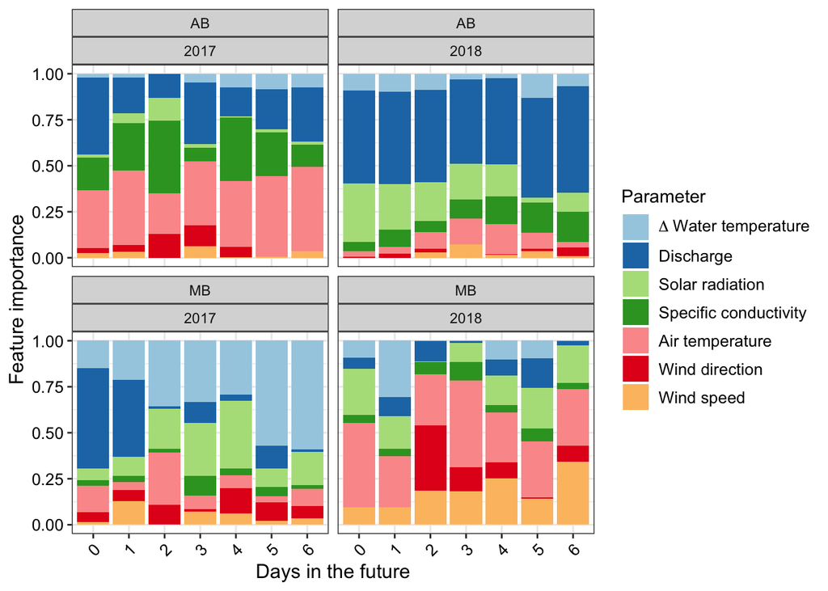

```r
#combine outputs into one dataset to make plot
results_1 <- rbind(ab17, ab18, mb17, mb18)

results_1 %>%
  ggplot() +
  geom_bar(aes(x = as.factor(DayinFuture), y = FeatureImportance, fill = Parameter),
           stat = 'identity')+
  scale_y_continuous(limits = c(0, 1),
                     name = "Feature importance") +
  scale_fill_brewer(palette = "Paired", labels = c(Delta~"Water temperature", "Discharge", "Solar radiation", "Specific conductivity", "Air temperature", "Wind direction", "Wind speed"))+
  xlab("Days in the future")+
  #expand = c(0,0))+
  theme_bw()+
  theme(
        axis.title = element_text(size = 12),
        axis.text = element_text(size =10, colour = "black"),
        legend.text = element_text(size = 10),
        legend.text.align = 0,
        axis.text.x = element_text(angle = 45, hjust = 1))+
  facet_wrap(~bay+year)
```

### 2. Keep all data together - combined bay and year

- to-do: figure how to run chege’s code with categorical variables, check the old, original code chege uploaded !
- i figured out the function i wrote wasn’t working with the bays and years combined because i had changed them to categorical varaibles for the above analysis to separate them and make 4 plots
- now i need to go back and change “bay” and “year” to 0’s and 1’s: 2017 = 0, 2018 = 1, MB = 0, “AB” = 1.

```r
#first need to convert the categorical variables back into numeric
#want to keep the original column to make sure it's correct
db$bayNUM <- db$bay
levels(db$bayNUM) <- c(0,1) #0 is MB, 1 is AB
#now for year
db$yearNUM <- db$year
levels(db$yearNUM) <- c(0, 1) #0 is 2017, 1 is 2018

#looks good, now i need to make them numbers and take out the categorical variables
dbALL <- db %>%
  mutate(bayNUM = as.numeric(bayNUM),
         yearNUM = as.numeric(yearNUM))  %>%
  select(-c(bay, year))
#weird i automatically changed 0 and 1 to 1 and 2, not sure if that matters

#i thought i needed to create a sparse matrix for the categorical variables to work but i'm 99% sure the results are exactly the same...here's the code but i didn't work it into the function because the test run i did with just one day of data was the same

# test <- db %>%
#   filter(DayinFuture == 1) %>%
#   select(-DayinFuture)
#
#
# sparse_matrix <- sparse.model.matrix(PCMean ~ .,
#                                      data = test,
#                                      contrasts.arg=list(bay=diag(nlevels(db$bay)),
#             year=diag(nlevels(db$year))))[,-1]
# head(sparse_matrix)


myList=NULL
df=NULL
datalist = list()
######################all data ##############################
for (i in 1:7) {
  temp <- dbALL[(dbALL$DayinFuture == i),]
  df <- featImportance(temp)
  datalist[[i]] <- df

}
###############################################################
```

#### 2.1 Plot: stacked bar chart - all data combined

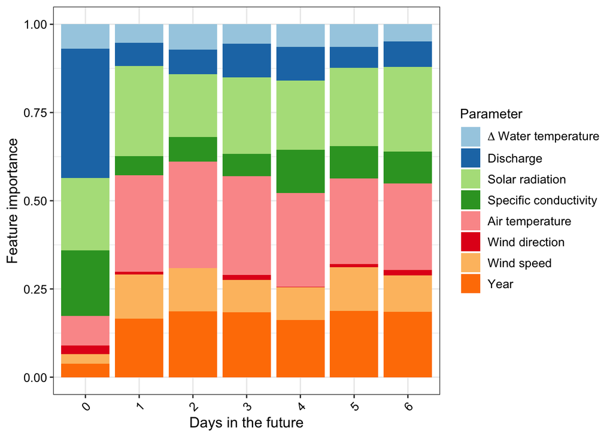

```r
#combine outputs into one dataset to make plot
results_2 <- do.call(rbind, datalist)

results_2 %>%
  ggplot() +
  geom_bar(aes(x = as.factor(DayinFuture), y = FeatureImportance, fill = Parameter),
           stat = 'identity') +
  scale_y_continuous(limits = c(0, 1),
                     name = "Feature importance") +
  scale_fill_brewer(palette = "Paired", labels = c(Delta~"Water temperature", "Discharge", "Solar radiation", "Specific conductivity", "Air temperature", "Wind direction", "Wind speed", "Year"))+
  xlab("Days in the future")+
  #expand = c(0,0))+
  theme_bw()+
  theme(
        axis.title = element_text(size = 12),
        axis.text = element_text(size =10, colour = "black"),
        legend.text = element_text(size = 10),
        legend.text.align = 0,
        axis.text.x = element_text(angle = 45, hjust = 1))
```

### 3. Separate by bay

#### 3.1 Plot: stacked bar chart - separated by bay

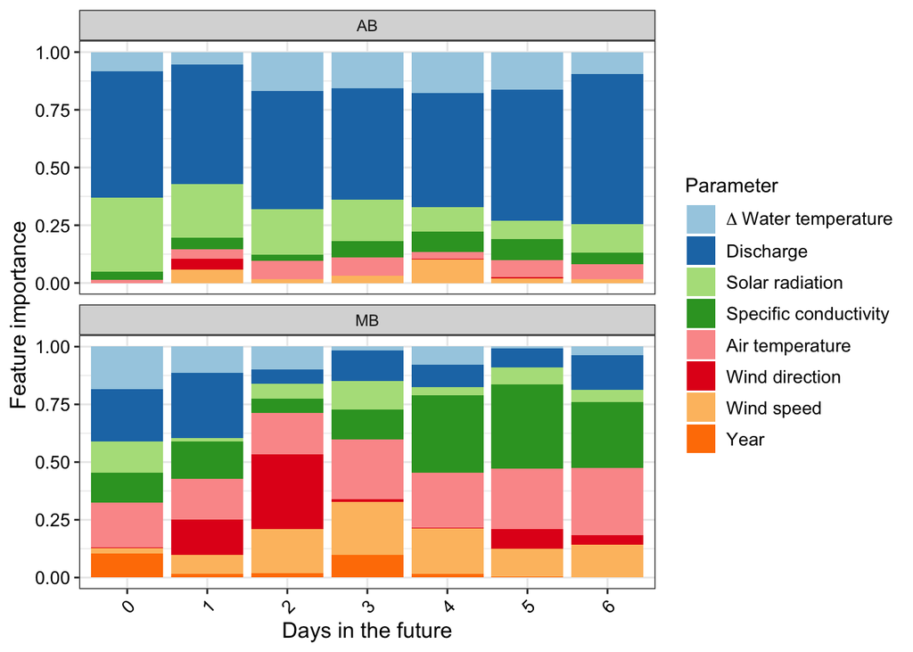

```r
#combine outputs into one dataset to make plot
results_3 <- rbind(ab, mb)

results_3 %>%
  ggplot() +
  geom_bar(aes(x = as.factor(DayinFuture), y = FeatureImportance, fill = Parameter),
           stat = 'identity') +
  scale_y_continuous(limits = c(0, 1),
                     name = "Feature importance") +
  scale_fill_brewer(palette = "Paired", labels = c(Delta~"Water temperature", "Discharge", "Solar radiation", "Specific conductivity", "Air temperature", "Wind direction", "Wind speed", "Year"))+
  xlab("Days in the future")+
  #expand = c(0,0))+
  theme_bw()+
  theme(
        axis.title = element_text(size = 12),
        axis.text = element_text(size =10, colour = "black"),
        legend.text = element_text(size = 10),
        legend.text.align = 0,
        axis.text.x = element_text(angle = 45, hjust = 1))+
  facet_wrap(~bay, nrow = 2)
```

### 4. Separate by year

#### 4.1 Plot: stacked bar chart - separated by year

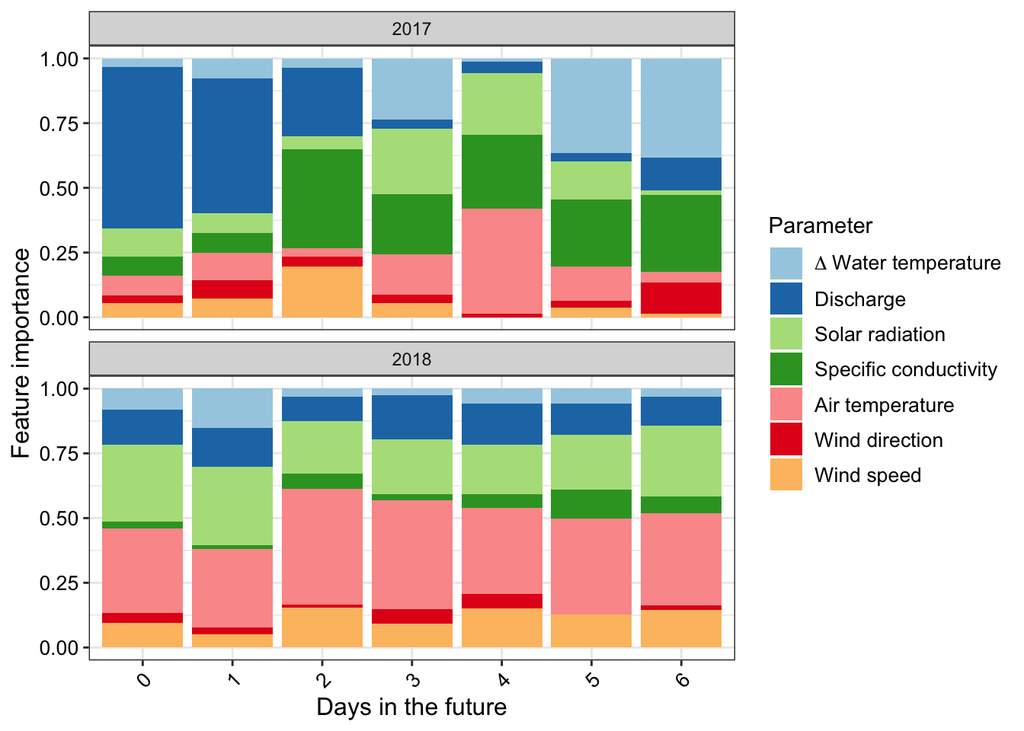

```r
#combine outputs into one dataset to make plot
results_4 <- rbind(db17, db18)

results_4 %>%
  ggplot() +
  geom_bar(aes(x = as.factor(DayinFuture), y = FeatureImportance, fill = Parameter),
           stat = 'identity') +
  scale_y_continuous(limits = c(0, 1),
                     name = "Feature importance") +
  scale_fill_brewer(palette = "Paired", labels = c(Delta~"Water temperature", "Discharge", "Solar radiation", "Specific conductivity", "Air temperature", "Wind direction", "Wind speed"))+
  xlab("Days in the future")+
  #expand = c(0,0))+
  theme_bw()+
  theme(
        axis.title = element_text(size = 12),
        axis.text = element_text(size =10, colour = "black"),
        legend.text = element_text(size = 10),
        legend.text.align = 0,
        axis.text.x = element_text(angle = 45, hjust = 1))+
  facet_wrap(~year, nrow = 2)
```